# Entropy rates from human DNA - results

First, the algorith written in Python3 was tested against a very long english text - the text was adjusted for words and spaces. The adjusted text has 6 115 909 letters.

Division of sequencies of the Homo Sapiens genome We divided the sequences of the Homo Sapiens genome into two parts: 1. sequencies of the Homo Sapiens genome, which vary only a little among people - sequencioes of coding genes. As a base we downloaded the file Homo_sapiens.GRCh38.cdna.all.fa.gz from ftp://ftp.ensembl.org/pub/release-99/fasta/homo_sapiens/cdna/ There are the sequencies of coding genes }i.e. the file of many shorter parts (not a continual long part). 2. sequencies of the Homo Sapiens genome, which vary among people. But not the whole sequencies, only small parts of them. We choose among-genes sequencies, which we downloaded from ftp://ftp.ensembl.org/pub/release-99/fasta/homo_sapiens/dna/ and filtered out the sequencies parts, which are in the file Homo_sapiens.GRCh38.99.gtf.gz from ftp://ftp.ensembl.org/pub/release-99/gtf/homo_sapiens/. This gtf file shows us, where the gene sequencies placed. So we filtered out the gene sequencies and worked onlz with the among-genes sequencies. DNA (Deoxyribonucleic acid) Deoxyribonucleic acid is a molecule which consists of two chains that form a double helix with genetic information of life organisms. The two DNA strands are called polynucleotides and are composed of monomeric units called nucleotides.Each nucleotide is composed of one of four nitrogen-containing nucleobases (cytosine [C], guanine [G], adenine [A] or thymine [T]). The nitrogenous bases of the two separate polynucleotide strands are bound together, according to base pairing rules (A with T and C with G), with hydrogen bonds to make double-stranded DNA. The nitrogenous bases are divided into two groups, pyrimidines (thymine and cytosine) and purines (adenine and guanine). A large part of DNA (in case of humas it is more than 98 %) is non-coding. Humans are eukaryotic organisms and store most of their DNA inside the cell nucleus as nuclear DNA. DNA of eukaryotic organism is organized into structures called chromosomes. In our survey, we took as the base samples contaning 1 000 000 and 10 000 000 of DNA letter (ATCG) of the human genome - chromosome 22.

```python
import pandas as pd
```

```python
import matplotlib.pyplot as plt
import matplotlib as mpl
from matplotlib.pyplot import figure
from pylab import rcParams
import random as rd
import secrets as sc
```

```python
from collections import OrderedDict as od
```

# Creating entropy rates

import libraries

```python
import re
import string as st
import random as rd
import secrets as sc
import math
from collections import OrderedDict as od  # to keep the order in dictionary
from collections import deque
```

constants

```python
letters=st.ascii_lowercase + ' '+'\n'
#letters='ATCG'
how_many_letters = 15
up_to=1000000
```

files

```python
source_file_in = 'big_english.txt'
source_adjusted_file_in = '1000000_english_adjusted.txt'
random_file_in = 'random_ab_english.txt'
```

data input preparing adjust the text file for processing and pick up all letters

```python
f_out=open(source_adjusted_file_in,'w')

with open(source_file_in,'r') as f_in:
   line = f_in.readline()
   cnt=0
   while line:
       for i in line:
           if i in letters:
               f_out.write(i.lower())
               cnt += 1
       line = f_in.readline()

       if cnt >= up_to:
           break


f_out.close()
f_in.close()
```

create the real random file for comparison, same length

```python
cnt=up_to

f_out=open(random_file_in,'w')
for i in range(cnt):
    # f_out.write(sc.choice(letters))
    if i%2:
        f_out.write('A')
    else:
        f_out.write('B')
f_out.close()
```

methods

```python
def count_mod_and_stat(adjusted_file_in, part_of_letters):         #Markov
    d_stat=od()
    d_mod=od()

    f_in=open(adjusted_file_in,'r')
    rows_in = f_in.read()

    moving_window = deque(maxlen = part_of_letters)

    for j in rows_in:

        key=''.join(moving_window)
        moving_window.append(j)
##      print(part_of_letters,key)
        if len(key) == part_of_letters:
            if key not in d_mod:
                d_mod[key] = od()

            if j in d_mod[key]:
                d_mod[key][j] += 1
            else:
                d_mod[key][j] = 1

            if key in d_stat:
                d_stat[key] += 1
            else:
                d_stat[key] = 1

    f_in.close()
    return d_mod,d_stat
```

count entropy and entropy rate for each number of letters

```python
def entropy_for_key(d_mod_part, d_stat_part):
	return -sum(v / d_stat_part * math.log2(v / d_stat_part) for v in d_mod_part.values())
```

```python
def entropy_rate(model, stats):
	return sum(stats[stat] * entropy_for_key(model[stat], stats[stat]) for stat in stats) / sum(stats.values())
```

program body

```python
print('Big English 6.140.000 letters - entropy rates')

for i in range(1,how_many_letters+1):
    d1_mod,d1_stat = count_mod_and_stat(source_adjusted_file_in,i)   # mod and stat big english
    print('Entropy rate for {0} is {1:.15f}'.format(i,entropy_rate(d1_mod, d1_stat)))
```

```python
print('Random regular ASCII AB letters - entropy rates')

for i in range(1,how_many_letters+1):
    d2_mod,d2_stat = count_mod_and_stat(random_file_in,i)   # random ascii letters
    print('Entropy rate for {0} is {1:.15f}'.format(i,entropy_rate(d2_mod, d2_stat)))
```

# English text

## English text - both 6.115.909,1.000.000 and 100.000 letters

picture 1 Big English 6.115.909 letters - entropy rates Entropy rate for 1 is 3.460560298465656 Entropy rate for 2 is 2.853339741215609 Entropy rate for 3 is 2.284627337678639 Entropy rate for 4 is 1.877331834992561 Entropy rate for 5 is 1.609899028147128 Entropy rate for 6 is 1.381407176382978 Entropy rate for 7 is 1.160374310358073 Entropy rate for 8 is 0.943698276824042 Entropy rate for 9 is 0.742511063868293 Entropy rate for 10 is 0.568542262899348 Entropy rate for 11 is 0.420972284836017 Entropy rate for 12 is 0.303429814112921 Entropy rate for 13 is 0.216545211081714 Entropy rate for 14 is 0.153859859608312 Entropy rate for 15 is 0.108873244052455 English 1000000 letters - entropy rates Entropy rate for 1 is 3.385798541788688 Entropy rate for 2 is 2.756335688340758 Entropy rate for 3 is 2.176524765137223 Entropy rate for 4 is 1.735751252876911 Entropy rate for 5 is 1.411371988398602 Entropy rate for 6 is 1.139266858667759 Entropy rate for 7 is 0.891802151225612 Entropy rate for 8 is 0.670864757304977 Entropy rate for 9 is 0.489733408104697 Entropy rate for 10 is 0.350246401563375 Entropy rate for 11 is 0.242717087017358 Entropy rate for 12 is 0.165368123241793 Entropy rate for 13 is 0.113927451884935 Entropy rate for 14 is 0.078419223233546 Entropy rate for 15 is 0.054101058523598 English 100000 letters - entropy rates Entropy rate for 1 is 3.333319012764591 Entropy rate for 2 is 2.640964523840834 Entropy rate for 3 is 1.967150009230119 Entropy rate for 4 is 1.426031197887872 Entropy rate for 5 is 1.021551510028821 Entropy rate for 6 is 0.723646132668534 Entropy rate for 7 is 0.489738952257133 Entropy rate for 8 is 0.319272029385776 Entropy rate for 9 is 0.206969336802574 Entropy rate for 10 is 0.133080208039241 Entropy rate for 11 is 0.083732655446321 Entropy rate for 12 is 0.053882770212694 Entropy rate for 13 is 0.036400764772944 Entropy rate for 14 is 0.024790394797998 Entropy rate for 15 is 0.016915721774567

```python
#dna=pd.read_excel('entropy_rates.xlsx',skiprows=[0,1,2,3,4,5,6],header=None)
dna=pd.read_excel('pictures/pic1.xlsx',header=None)
d_dna=od()
```

```python
for i in dna.values:
    if i != None:
        #print(i)
        if 'Entropy' in i[0]:
            d_dna[key[0]].append([int(i[0].split()[3]),float(i[0].split()[5])])

        elif 'letters' in i[0]:
            key=i
            d_dna[key[0]]=[]
```

```python
# Changing default values for parameters individually
plt.ioff()

plt.rc('lines', linewidth=2, linestyle='-')
plt.rcParams['lines.markersize'] = 14
plt.rcParams['font.size'] = '20.0'
```

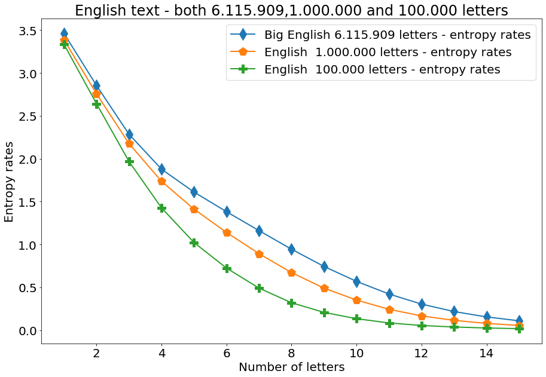

```python
fig, ax = plt.subplots(figsize=(15, 10))
ax.set(title = "English text - both 6.115.909,1.000.000 and 100.000 letters",
       xlabel = "Number of letters",
       ylabel = "Entropy rates")
for k,v in d_dna.items():
    ax.plot(list(map(lambda u:u[0],v)),list(map(lambda u:u[1],v)),label=k,marker=rd.choice(['*','.','p','X','h','H','d','P','<','>','1']))
#plt.plot([0,15], [1,1], 'k--',linewidth=3)
plt.legend()
plt.show()
```

## English text - random 6.115.909,1.000.000 and 100.000 letters

picture 3 Random ASCII 6.115.909 letters - entropy rates Entropy rate for 1 is 5.727603017070786 Entropy rate for 2 is 5.710452149151111 Entropy rate for 3 is 4.710745764787761 Entropy rate for 4 is 0.652956723480869 Random ASCII 1.000.000 letters - entropy rates Entropy rate for 1 is 5.726016902018641 Entropy rate for 2 is 5.619168850704395 Entropy rate for 3 is 2.734462165629759 Entropy rate for 4 is 0.121675470857184 Entropy rate for 5 is 0.002308011540058 Entropy rate for 6 is 0.000046000276002 Entropy rate for 7 is 0.000002000014000 Entropy rate for 8 is 0.000000000000000 Entropy rate for 9 is 0.000000000000000 Entropy rate for 10 is 0.000000000000000 Entropy rate for 11 is 0.000000000000000 Entropy rate for 12 is 0.000000000000000 Entropy rate for 13 is 0.000000000000000 Entropy rate for 14 is 0.000000000000000 Entropy rate for 15 is 0.000000000000000 Random ASCII 100.000 letters - entropy rates Entropy rate for 1 is 5.708562355695650 Entropy rate for 2 is 4.584896966870098 Entropy rate for 3 is 0.576265772947634 Entropy rate for 4 is 0.012008029196189 Entropy rate for 5 is 0.000340017000850 Entropy rate for 6 is 0.000020001200072 Entropy rate for 7 is 0.000000000000000 Entropy rate for 8 is 0.000000000000000 Entropy rate for 9 is 0.000000000000000 Entropy rate for 10 is 0.000000000000000 Entropy rate for 11 is 0.000000000000000 Entropy rate for 12 is 0.000000000000000 Entropy rate for 13 is 0.000000000000000 Entropy rate for 14 is 0.000000000000000 Entropy rate for 15 is 0.000000000000000

```python
#dna=pd.read_excel('entropy_rates.xlsx',skiprows=[0,1,2,3,4,5,6],header=None)
dna=pd.read_excel('pictures/pic3.xlsx',header=None)
d_dna=od()
```

```python
for i in dna.values:
    if i != None:
        #print(i)
        if 'Entropy' in i[0]:
            d_dna[key[0]].append([int(i[0].split()[3]),float(i[0].split()[5])])

        elif 'Random' in i[0]:
            key=i
            d_dna[key[0]]=[]
```

```python
# Changing default values for parameters individually
plt.ioff()

plt.rc('lines', linewidth=2, linestyle='-')
plt.rcParams['lines.markersize'] = 14
plt.rcParams['font.size'] = '20.0'
```

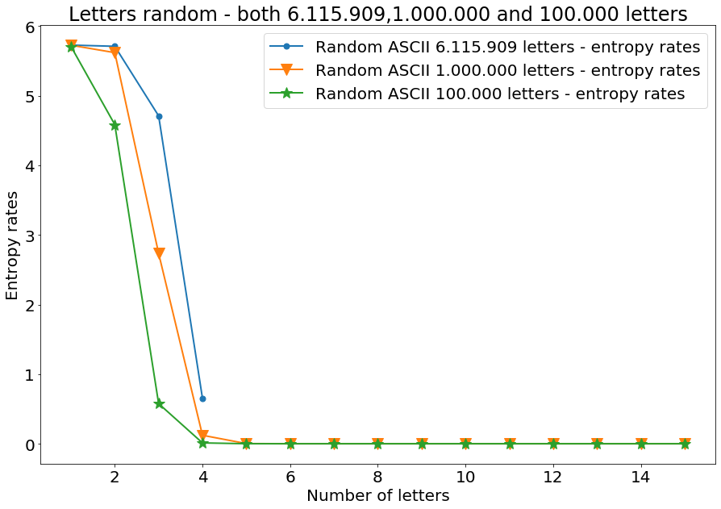

```python
fig, ax = plt.subplots(figsize=(15, 10))
ax.set(title = "Letters random - both 6.115.909,1.000.000 and 100.000 letters",
       xlabel = "Number of letters",
       ylabel = "Entropy rates")
for k,v in d_dna.items():
    ax.plot(list(map(lambda u:u[0],v)),list(map(lambda u:u[1],v)),label=k,marker=rd.choice(['*','.','p','X','v']))
#plt.plot([0,15], [1,1], 'k--',linewidth=3)
plt.legend()
plt.show()
```

## Random ASCII lower letters + ' '+'new line' 1.000.000, and random AB

Random ASCII 1.000.000 letters - entropy rates Entropy rate for 1 is 4.806806415792377 Entropy rate for 2 is 4.791845636924649 Entropy rate for 3 is 4.309770757871457 Entropy rate for 4 is 1.157895784334135 Entropy rate for 5 is 0.055724447198417 Entropy rate for 6 is 0.002096012576075 Entropy rate for 7 is 0.000082000574004 Entropy rate for 8 is 0.000000000000000 Entropy rate for 9 is 0.000000000000000 Entropy rate for 10 is 0.000000000000000 Entropy rate for 11 is 0.000000000000000 Entropy rate for 12 is 0.000000000000000 Entropy rate for 13 is 0.000000000000000 Entropy rate for 14 is 0.000000000000000 Entropy rate for 15 is 0.000000000000000 Random ASCII AB 1.000.000 letters - entropy rates Entropy rate for 1 is 0.999999634480358 Entropy rate for 2 is 0.999998556197386 Entropy rate for 3 is 0.999996562695128 Entropy rate for 4 is 0.999992221577087 Entropy rate for 5 is 0.999981276292896 Entropy rate for 6 is 0.999962027589731 Entropy rate for 7 is 0.999911839086413 Entropy rate for 8 is 0.999805697405878 Entropy rate for 9 is 0.999620269303990 Entropy rate for 10 is 0.999279505011282 Entropy rate for 11 is 0.998566123143453 Entropy rate for 12 is 0.997080924051411 Entropy rate for 13 is 0.994019712964671 Entropy rate for 14 is 0.988088063802792 Entropy rate for 15 is 0.975842205202727

```python
#dna=pd.read_excel('entropy_rates.xlsx',skiprows=[0,1,2,3,4,5,6],header=None)
dna=pd.read_excel('pictures/random_playing.xlsx',header=None)
d_dna=od()
```

```python
for i in dna.values:
    if i != None:
        #print(i)
        if 'Entropy' in i[0]:
            d_dna[key[0]].append([int(i[0].split()[3]),float(i[0].split()[5])])

        elif 'Random' in i[0]:
            key=i
            d_dna[key[0]]=[]
```

```python
# Changing default values for parameters individually
plt.ioff()

plt.rc('lines', linewidth=2, linestyle='-')
plt.rcParams['lines.markersize'] = 14
plt.rcParams['font.size'] = '20.0'
```

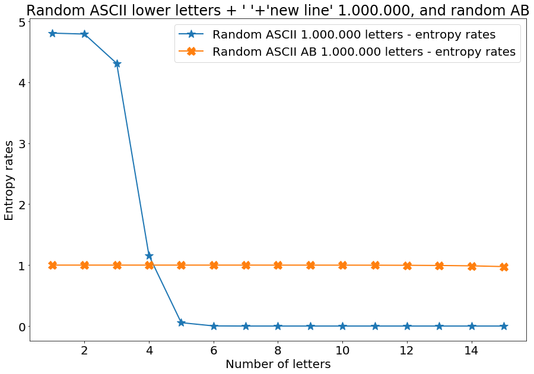

```python
fig, ax = plt.subplots(figsize=(15, 10))
ax.set(title = "Random ASCII lower letters + ' '+'new line' 1.000.000, and random AB",
       xlabel = "Number of letters",
       ylabel = "Entropy rates")
for k,v in d_dna.items():
    ax.plot(list(map(lambda u:u[0],v)),list(map(lambda u:u[1],v)),label=k,marker=sc.choice(['*','.','p','X','v']))
#plt.plot([0,15], [1,1], 'k--',linewidth=3)
plt.legend()
plt.show()
```

# DNA

## DNA human chr.22 - 10.000.000,1.000.000 and 100.000 letters

picture 4 DNA Homo Sapiens chr.22 100000 letters - entropy rates Entropy rate for 1 is 1.913362274396372 Entropy rate for 2 is 1.900347823224718 Entropy rate for 3 is 1.887723229207341 Entropy rate for 4 is 1.873137840693941 Entropy rate for 5 is 1.843727964696182 Entropy rate for 6 is 1.761186473981162 Entropy rate for 7 is 1.522076484403815 Entropy rate for 8 is 1.025374648685397 Entropy rate for 9 is 0.504356455894060 Entropy rate for 10 is 0.211136421707204 Entropy rate for 11 is 0.086274327668645 Entropy rate for 12 is 0.038948435707260 Entropy rate for 13 is 0.021425686599036 Entropy rate for 14 is 0.014872666031040 Entropy rate for 15 is 0.011499310841891 DNA Homo Sapiens chr.22 1000000 letters - entropy rates Entropy rate for 1 is 1.935015017905594 Entropy rate for 2 is 1.922691995772603 Entropy rate for 3 is 1.917231199136902 Entropy rate for 4 is 1.906694153566108 Entropy rate for 5 is 1.888836646226178 Entropy rate for 6 is 1.854677723109807 Entropy rate for 7 is 1.786240867635828 Entropy rate for 8 is 1.624632667836778 Entropy rate for 9 is 1.258660768185314 Entropy rate for 10 is 0.736069664974026 Entropy rate for 11 is 0.351857698084421 Entropy rate for 12 is 0.169260779220479 Entropy rate for 13 is 0.096230448430386 Entropy rate for 14 is 0.067034305390105 Entropy rate for 15 is 0.052834941539676 DNA Homo Sapiens chr.22 10000000 letters - entropy rates Entropy rate for 1 is 1.945013466665666 Entropy rate for 2 is 1.929034964237023 Entropy rate for 3 is 1.917653626573821 Entropy rate for 4 is 1.892089910119932 Entropy rate for 5 is 1.838632970799868 Entropy rate for 6 is 1.748396923857422 Entropy rate for 7 is 1.643718326544159 Entropy rate for 8 is 1.535131205192176 Entropy rate for 9 is 1.399855198267327 Entropy rate for 10 is 1.166106346754825 Entropy rate for 11 is 0.790660826268630 Entropy rate for 12 is 0.441615165770775 Entropy rate for 13 is 0.248131027263446 Entropy rate for 14 is 0.165001217798250 Entropy rate for 15 is 0.129498973126305

```python
#dna=pd.read_excel('entropy_rates.xlsx',skiprows=[0,1,2,3,4,5,6],header=None)
dna=pd.read_excel('pictures/pic4.xlsx',header=None)
d_dna=od()
```

```python
for i in dna.values:
    if i != None:
        #print(i)
        if 'Entropy' in i[0]:
            d_dna[key[0]].append([int(i[0].split()[3]),float(i[0].split()[5])])

        elif 'DNA' in i[0]:
            key=i
            d_dna[key[0]]=[]
```

```python
# Changing default values for parameters individually
plt.ioff()

plt.rc('lines', linewidth=2, linestyle='-')
plt.rcParams['lines.markersize'] = 14
plt.rcParams['font.size'] = '20.0'
```

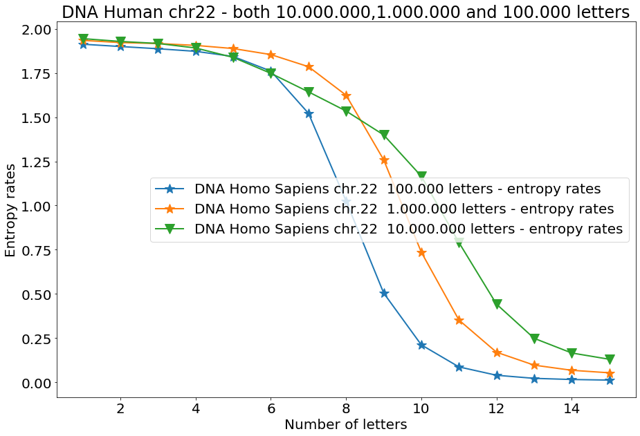

```python
fig, ax = plt.subplots(figsize=(15, 10))
ax.set(title = "DNA Human chr22 - both 10.000.000,1.000.000 and 100.000 letters",
       xlabel = "Number of letters",
       ylabel = "Entropy rates")
for k,v in d_dna.items():
    ax.plot(list(map(lambda u:u[0],v)),list(map(lambda u:u[1],v)),label=k,marker=rd.choice(['*','.','p','X','v']))
#plt.plot([0,15], [1,1], 'k--',linewidth=3)
plt.legend()
plt.show()
```

## Random "ATCG" 10.000.000, 1.000.000, 100.000 letters - entropy rates

picture 5 Random "ATCG" 100.000 letters - entropy rates Entropy rate for 1 is 1.999907232195984 Entropy rate for 2 is 1.999533196977411 Entropy rate for 3 is 1.998531093014957 Entropy rate for 4 is 1.994322137561205 Entropy rate for 5 is 1.978368359574361 Entropy rate for 6 is 1.907749938760297 Entropy rate for 7 is 1.578102572434652 Entropy rate for 8 is 0.801030931099922 Entropy rate for 9 is 0.259915943360126 Entropy rate for 10 is 0.070059637841056 Entropy rate for 11 is 0.017139629734379 Entropy rate for 12 is 0.003700444053286 Entropy rate for 13 is 0.000800104013522 Entropy rate for 14 is 0.000300042005881 Entropy rate for 15 is 0.000060009001350 Random "ATCG" 1.000.000 letters - entropy rates Entropy rate for 1 is 1.999994290111202 Entropy rate for 2 is 1.999976936087742 Entropy rate for 3 is 1.999895566910539 Entropy rate for 4 is 1.999444337073500 Entropy rate for 5 is 1.997793875916525 Entropy rate for 6 is 1.991107911964216 Entropy rate for 7 is 1.964317258663300 Entropy rate for 8 is 1.846804466034583 Entropy rate for 9 is 1.338735399975344 Entropy rate for 10 is 0.567306244095087 Entropy rate for 11 is 0.167979896331832 Entropy rate for 12 is 0.043373395806801 Entropy rate for 13 is 0.011043809744600 Entropy rate for 14 is 0.002801548996690 Entropy rate for 15 is 0.000728010920164 Random "ATCG" 10.000.000 letters - entropy rates Entropy rate for 1 is 1.999999621179243 Entropy rate for 2 is 1.999996846174615 Entropy rate for 3 is 1.999986219563596 Entropy rate for 4 is 1.999941636552967 Entropy rate for 5 is 1.999782404319651 Entropy rate for 6 is 1.999105907559789 Entropy rate for 7 is 1.996417788168553 Entropy rate for 8 is 1.985678200045927 Entropy rate for 9 is 1.941798509798605 Entropy rate for 10 is 1.737878430824742 Entropy rate for 11 is 1.062413454027464 Entropy rate for 12 is 0.385736209404728

```python
#dna=pd.read_excel('entropy_rates.xlsx',skiprows=[0,1,2,3,4,5,6],header=None)
dna=pd.read_excel('pictures/pic5.xlsx',header=None)
d_dna=od()
```

```python
for i in dna.values:
    if i != None:
        #print(i)
        if 'Entropy' in i[0]:
            d_dna[key[0]].append([int(i[0].split()[3]),float(i[0].split()[5])])

        elif 'Random' in i[0]:
            key=i
            d_dna[key[0]]=[]
```

```python
# Changing default values for parameters individually
plt.ioff()

plt.rc('lines', linewidth=2, linestyle='-')
plt.rcParams['lines.markersize'] = 14
plt.rcParams['font.size'] = '20.0'
```

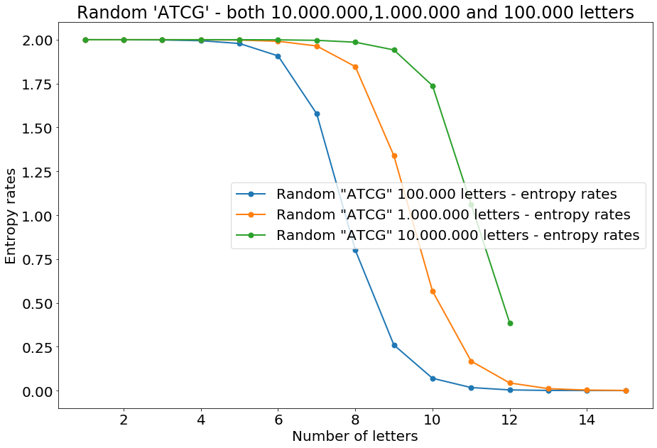

```python
fig, ax = plt.subplots(figsize=(15, 10))
ax.set(title = "Random 'ATCG' - both 10.000.000,1.000.000 and 100.000 letters",
       xlabel = "Number of letters",
       ylabel = "Entropy rates")
for k,v in d_dna.items():
    ax.plot(list(map(lambda u:u[0],v)),list(map(lambda u:u[1],v)),label=k,marker=rd.choice(['*','.','p','X','v']))
#plt.plot([0,15], [1,1], 'k--',linewidth=3)
plt.legend()
plt.show()
```

## DNA human chr.22 - 1.000.000 - genes (stable),outside genes (variable)

picture 6 DNA Homo Sapiens ouside genes chr.22 1.000.000 letters - entropy rates Entropy rate for 1 is 1.948633491735757 Entropy rate for 2 is 1.934789275924409 Entropy rate for 3 is 1.926129355989104 Entropy rate for 4 is 1.914985690410224 Entropy rate for 5 is 1.897290673308529 Entropy rate for 6 is 1.866388256809019 Entropy rate for 7 is 1.829789686873500 Entropy rate for 8 is 1.783818234401174 Entropy rate for 9 is 1.712673691697246 Entropy rate for 10 is 1.561530741335917 Entropy rate for 11 is 1.245403627631284 Entropy rate for 12 is 0.785243727039682 Entropy rate for 13 is 0.402255394471529 DNA Homo Sapiens only genes chr.22 1.000.000 letters - entropy rates Entropy rate for 1 is 1.946480256496254 Entropy rate for 2 is 1.931920867122660 Entropy rate for 3 is 1.922877582547098 Entropy rate for 4 is 1.910409350289652 Entropy rate for 5 is 1.889866379517720 Entropy rate for 6 is 1.855457862670974 Entropy rate for 7 is 1.816131134384377 Entropy rate for 8 is 1.771282761458401 Entropy rate for 9 is 1.711921948201891 Entropy rate for 10 is 1.589363414072911 Entropy rate for 11 is 1.299160829801111 Entropy rate for 12 is 0.829138753331100 Entropy rate for 13 is 0.426335940576366 Entropy rate for 14 is 0.214139592869961 Entropy rate for 15 is 0.126929139958313

```python
#dna=pd.read_excel('entropy_rates.xlsx',skiprows=[0,1,2,3,4,5,6],header=None)
dna=pd.read_excel('pictures/pic6.xlsx',header=None)
d_dna=od()
```

```python
for i in dna.values:
    if i != None:
        #print(i)
        if 'Entropy' in i[0]:
            d_dna[key[0]].append([int(i[0].split()[3]),float(i[0].split()[5])])

        elif 'DNA' in i[0] or 'Random' in i[0]:
            key=i
            d_dna[key[0]]=[]
```

```python
# Changing default values for parameters individually
plt.ioff()

plt.rc('lines', linewidth=2, linestyle='-')
plt.rcParams['lines.markersize'] = 14
plt.rcParams['font.size'] = '20.0'
```

[figure not shown]

```python
fig, ax = plt.subplots(figsize=(15, 10))
ax.set(title = "DNA human chr.22 - 1.000.000 - genes (stable),outside genes (variable)",
       xlabel = "Number of letters",
       ylabel = "Entropy rates")
for k,v in d_dna.items():
    ax.plot(list(map(lambda u:u[0],v)),list(map(lambda u:u[1],v)),label=k,marker=rd.choice(['*','.','p','X','v']))

#plt.plot([0,15], [1,1], 'k--',linewidth=3)
plt.legend()
plt.show()
```

# DNA Homo Sapiens - outside genes information variable human to human

### Filtration of information outside genes from fasta file of Human Genome

```python
from BCBio.GFF import GFFExaminer
from Bio import SeqIO
from pyfaidx import Fasta
import gffutils
```

### Homo Sapiens chromosome 22 outside genes

```python
db=gffutils.create_db('unstable/Homo_sapiens.GRCh38.99.chromosome.22.gff3',dbfn='homo_out_genes22.db',force=True,keep_order=True,merge_strategy='merge',sort_attribute_values=True)
```

```python
db=gffutils.FeatureDB('homo_out_genes22.db',keep_order=True)
```

```python
#f=Fasta('unstable/Homo_sapiens.GRCh38.dna.chromosome.22.fa')
chr22 = next(SeqIO.parse('unstable/Homo_sapiens.GRCh38.dna.chromosome.22.fa','fasta'))
```

```python
print(list(db.featuretypes()))
```

[output not shown]

```python
chr22_seq=open('unstable/chr22_seq.txt','w')
```

```python
for i in range(len(not_genes)):
    try:
        #print(not_genes[i].attributes.items()[0][1][0],not_genes[i].start,not_genes[i].stop)
        chr22_seq.write(str((chr22.seq[not_genes[i].start:not_genes[i].stop])))
    except Exception:
        pass
chr22_seq.close()
```

```python
dna=pd.read_excel('entropy_rates_final_DNAchrom22_1000000_outside_genes.xlsx',header=None)
```

```python
d_dna=od()
```

```python
for i in dna.values:
    if i != None:
        #print(i)
        if 'Entropy rate' in i[0]:
            d_dna[key[0]].append([int(i[0].split()[3]),float(i[0].split()[5])])

        elif '1000000' in i[0]:
            key=i
            d_dna[key[0]]=[]
```

```python
# Changing default values for parameters individually
plt.ioff()

plt.rc('lines', linewidth=2, linestyle='-', marker='.')
plt.rcParams['lines.markersize'] = 10
plt.rcParams['font.size'] = '10.0'
```

```python
fig, ax = plt.subplots(figsize=(15, 10))
ax.set(title = "DNA human chrom22 outside genes and random 'ATCG' - 1000000 letters",
       xlabel = "Number of letters",
       ylabel = "Entropy rates")
for k,v in d_dna.items():
    ax.plot(list(map(lambda u:u[0],v)),list(map(lambda u:u[1],v)),label=k)
plt.plot([0,15], [1,1], 'k--',linewidth=3)
plt.legend()
plt.show()
```

[output not shown]